# DATA SCIENCE LATAM

UN ESPACIO PARA NUNCA PARAR DE APRENDER!!

Francisco Zambrano Cruz. Mayo 2020.

[figure not shown]

# SUAVISADO EXPONENCIAL

Pre requisito: haber leido [Gráficos de series de tiempo](https://zpio.github.io/datascience/post/Gr%C3%A1ficos_Series_Tiempo_R.html) y [Descomposición de Series de Tiempo](https://zpio.github.io/datascience/post/Descomposicion_series_tiempo.html)

## 1. Suavizado Exponencial Simple

El más simple de los métodos de suavizado exponencial se llama naturalmente **suavizado exponencial simple (SES)**. Este método es adecuado para pronosticar datos sin tendencia clara o patrón estacional. Por ejemplo, los datos en la **Figura 1** no muestran ningún comportamiento de tendencia claro o estacionalidad. (Hay un aumento en los últimos años, lo que podría sugerir una tendencia. Consideraremos si un método de tendencia sería mejor para esta serie más adelante).

Figura 1: Producción de petróleo en Arabia Saudita de 1996 a 2013.

```r
library(ggplot2)
library(fpp2)
```

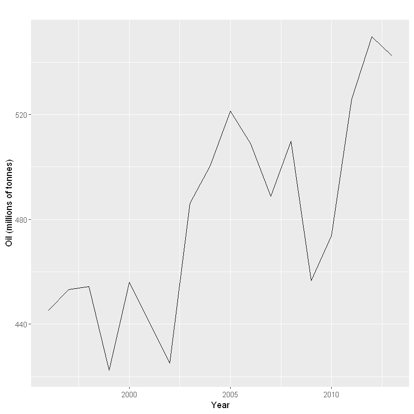

```r
oildata <- window(oil, start=1996)
autoplot(oildata) +
  ylab("Oil (millions of tonnes)") + xlab("Year")
```

Utilizando el **método Naive** (VER ANEXO, al final), todas las predicciones para el futuro son iguales al último valor observado de la serie. Por lo tanto, el método naive supone que la observación más reciente es la única importante, y todas las observaciones anteriores no proporcionan información para el futuro. Esto puede considerarse como un promedio ponderado donde se asigna todo el peso a la última observación.

Usando el **método Average**(VER ANEXO, al final), todos los pronósticos futuros son iguales a un promedio simple de los datos observados. Por lo tanto, el método promedio asume que todas las observaciones son de igual importancia y les da pesos iguales al generar pronósticos.

Puede ser sensato atribuir pesos más grandes a observaciones más recientes que a observaciones del pasado distante. Este es exactamente el concepto detrás del **suavizado exponencial simple**. Los pronósticos se calculan usando promedios ponderados, donde los pesos disminuyen exponencialmente a medida que las observaciones provienen de más allá en el pasado: los pesos más pequeños se asocian con las observaciones más antiguas:

$$\begin{equation} \hat{y}_{T+1|T} = \alpha y_T + \alpha(1-\alpha) y_{T-1} + \alpha(1-\alpha)^2 y_{T-2}+ \cdots, \tag{1} \end{equation}$$

donde $0 \le \alpha \le 1$ lees el parámetro de suavizado. El pronóstico de un paso adelante para el tiempo T+1 es un promedio ponderado de todas las observaciones de la serie $y_1,\dots,y_T$. La velocidad a la que disminuyen los pesos está controlada por el parámetro α.

La siguiente tabla muestra los pesos adjuntos a las observaciones para cuatro valores diferentes de αal pronosticar usando un suavizado exponencial simple. Tenga en cuenta que la suma de los pesos incluso para un valor pequeño de α será aproximadamente uno para cualquier tamaño de muestra razonable.

```r
#	     α=0.2	 α=0.4	 α=0.6	 α=0.8
#yT	    0.2000	0.4000	0.6000	0.8000
#yT-1	0.1600	0.2400	0.2400	0.1600
#yT-2	0,1280	0.1440	0,0960	0,0320
#yT-3	0.1024	0,0864	0,0384	0.0064
#yT-4	0,0819	0,0518	0,0154	0.0013
#yT-5	0,0655	0,0311	0.0061	0,0003
```

Para cualquier α entre 0 y 1, los pesos adjuntos a las observaciones disminuyen exponencialmente a medida que retrocedemos en el tiempo, de ahí el nombre de "**suavizado exponencial**". Si α es pequeño (es decir, cercano a 0), se le da más peso a las observaciones del pasado más lejano. Si α es grande (es decir, cercano a 1), se le da más peso a las observaciones más recientes. Para el caso extremo donde α=1, $\hat{y}_{T+1|T}=y_T$, y los pronósticos son iguales a los pronósticos Naives (ver Anexo, al final).

Presentamos dos formas equivalentes de suavizado exponencial simple, cada una de las cuales conduce a la ecuación de pronóstico (1)

### Forma promedio ponderada

El pronóstico en el momento T+1 es igual a un promedio ponderado entre la observación más reciente $y_T$ y la previsión anterior $\hat{y}_{T|T-1}$

$$\hat{y}_{T+1|t} = \alpha y_T + (1-\alpha) \hat{y}_{T|T-1}$$

donde 0 ≤ α ≤ 1 es el parámetro de suavizado. Del mismo modo, podemos escribir los valores ajustados como:

$$\hat{y}_{t+1|t} = \alpha y_t + (1-\alpha) \hat{y}_{t|t-1}$$

para t=1,...,T. (Recuerde que los valores ajustados son simplemente pronósticos de un paso de los datos de entrenamiento).

El proceso tiene que comenzar en alguna parte, por lo que dejamos que el primer valor ajustado en el tiempo 1 se denote por ℓ0 (que tendremos que estimar). Entonces:

$$\begin{align*} \hat{y}_{2|1} &= \alpha y_1 + (1-\alpha) \ell_0\\ \hat{y}_{3|2} &= \alpha y_2 + (1-\alpha) \hat{y}_{2|1}\\ \hat{y}_{4|3} &= \alpha y_3 + (1-\alpha) \hat{y}_{3|2}\\ \vdots\\ \hat{y}_{T|T-1} &= \alpha y_{T-1} + (1-\alpha) \hat{y}_{T-1|T-2}\\ \hat{y}_{T+1|T} &= \alpha y_T + (1-\alpha) \hat{y}_{T|T-1}. \end{align*}$$

Sustituyendo cada ecuación en la siguiente ecuación, obtenemos:

$$\begin{align*} \hat{y}_{3|2} & = \alpha y_2 + (1-\alpha) \left[\alpha y_1 + (1-\alpha) \ell_0\right] \\ & = \alpha y_2 + \alpha(1-\alpha) y_1 + (1-\alpha)^2 \ell_0 \\ \hat{y}_{4|3} & = \alpha y_3 + (1-\alpha) [\alpha y_2 + \alpha(1-\alpha) y_1 + (1-\alpha)^2 \ell_0]\\ & = \alpha y_3 + \alpha(1-\alpha) y_2 + \alpha(1-\alpha)^2 y_1 + (1-\alpha)^3 \ell_0 \\ & ~~\vdots \\ \hat{y}_{T+1|T} & = \sum_{j=0}^{T-1} \alpha(1-\alpha)^j y_{T-j} + (1-\alpha)^T \ell_{0}. \end{align*}$$

Entonces, la forma promedio ponderada conduce a la misma ecuación de pronóstico (1)

### Forma componente

Una representación alternativa es la forma del componente. Para el suavizado exponencial simple, el único componente incluido es el nivel, ℓt. (Otros métodos que se consideran que pueden incluir una tendencia bt y un componente estacional st.) Las representaciones en forma de componentes de los métodos de suavizado exponencial comprenden una ecuación de pronóstico y una ecuación de suavizado para cada uno de los componentes incluidos en el método. La forma del componente de suavizado exponencial simple viene dada por:

$$\begin{align*} \text{Forecast equation} && \hat{y}_{t+h|t} & = \ell_{t}\\ \text{Smoothing equation} && \ell_{t} & = \alpha y_{t} + (1 - \alpha)\ell_{t-1}, \end{align*}$$

donde ℓt es el nivel (o el valor suavizado) de la serie en el tiempo t. Ajuste h=1 da los valores ajustados, mientras establece t=T da los pronósticos verdaderos más allá de los datos de entrenamiento.

La ecuación de pronóstico muestra que el valor de pronóstico en el tiempo t+1 es el nivel estimado en el tiempo t. La ecuación de nivelación para el nivel (generalmente denominada ecuación de nivel) proporciona el nivel estimado de la serie en cada período t.

Si reemplazamos ℓt con $\hat{y}_{t+1|t}$ y ℓt-1 con $\hat{y}_{t|t-1}$ en la ecuación de suavizado, recuperaremos la forma promedio ponderada de suavizado exponencial simple.

La forma del componente de suavizado exponencial simple no es particularmente útil, pero será la forma más fácil de usar cuando comencemos a agregar otros componentes.

### Pronósticos flat

El suavizado exponencial simple tiene una función de pronóstico "flat" :

$$\hat{y}_{T+h|T} = \hat{y}_{T+1|T}=\ell_T, \qquad h=2,3,\dots$$

Es decir, todos los pronósticos toman el mismo valor, igual al componente de último nivel. Recuerde que estos pronósticos solo serán adecuados si la serie temporal no tiene tendencia o componente estacional.

### Mejoramiento

La aplicación de cada método de suavizado exponencial requiere que se elijan los parámetros de suavizado y los valores iniciales. En particular, para el suavizado exponencial simple, necesitamos seleccionar los valores de α y ℓ0. Todos los pronósticos se pueden calcular a partir de los datos una vez que conocemos esos valores. Para los métodos que siguen, generalmente hay más de un parámetro de suavizado y más de un componente inicial para elegir.

En algunos casos, los parámetros de suavizado pueden elegirse de manera subjetiva: el pronosticador especifica el valor de los parámetros de suavizado en función de la experiencia previa. Sin embargo, una forma más confiable y objetiva de obtener valores para los parámetros desconocidos es estimarlos a partir de los datos observados.

En regresion lineal estimamos los coeficientes de un modelo de regresión minimizando la suma de los residuos al cuadrado (generalmente conocido como SSE o "suma de errores al cuadrado"). Del mismo modo, los parámetros desconocidos y los valores iniciales para cualquier método de suavizado exponencial se pueden estimar minimizando el SSE.

Los residuos se especifican como: $e_t=y_t - \hat{y}_{t|t-1}$ para t=1,...,T. Por lo tanto, encontramos los valores de los parámetros desconocidos y los valores iniciales que minimizan

$$\begin{equation} \text{SSE}=\sum_{t=1}^T(y_t - \hat{y}_{t|t-1})^2=\sum_{t=1}^Te_t^2. \tag{2} \end{equation}$$

A diferencia del caso de regresión (donde tenemos fórmulas que devuelven los valores de los coeficientes de regresión que minimizan el SSE), esto implica un problema de minimización no lineal, y necesitamos usar una herramienta de optimización para resolverlo.

### Ejemplo: producción de petróleo

En este ejemplo, se aplica un suavizado exponencial simple para pronosticar la producción de petróleo en Arabia Saudita.

```r
oildata <- window(oil, start=1996)
# Estimate parameters
fc <- ses(oildata, h=5)
# Accuracy of one-step-ahead training errors
fc
round(accuracy(fc),2)
fc$model
```

```
     Point Forecast    Lo 80    Hi 80    Lo 95    Hi 95
2014       542.6806 504.4541 580.9070 484.2183 601.1429
2015       542.6806 492.9073 592.4539 466.5589 618.8023
2016       542.6806 483.5747 601.7864 452.2860 633.0752
2017       542.6806 475.5269 609.8343 439.9778 645.3834
2018       542.6806 468.3452 617.0159 428.9945 656.3667
```

|  | ME | RMSE | MAE | MPE | MAPE | MASE | ACF1 |
| --- | --- | --- | --- | --- | --- | --- | --- |
| Training set | 6.4 | 28.12 | 22.26 | 1.1 | 4.61 | 0.93 | -0.03 |

```
Simple exponential smoothing

Call:
 ses(y = oildata, h = 5)

  Smoothing parameters:
    alpha = 0.8339

  Initial states:
    l = 446.5868

  sigma:  29.8282

     AIC     AICc      BIC
178.1430 179.8573 180.8141
```

Esto da los parámetro estimados $\hat\alpha=0.83$ y $\hat\ell_0=446.6$, obtenido al minimizar la SSE durante los períodos t=1,2,…,18, sujeto a la restricción de que 0≤α≤1.

En la Tabla 1 demostramos el cálculo usando estos parámetros. La última columna muestra el nivel estimado para los tiempos t=0 a t=18; las últimas filas de la última columna muestran los pronósticos para h=1,2,3,4,5

Tabla 1: Previsión de la producción total de petróleo en millones de toneladas para Arabia Saudita utilizando un suavizado exponencial simple.

[figure not shown]

La línea negra en la Figura 2 es un gráfico de los datos, que muestra un nivel cambiante con el tiempo.

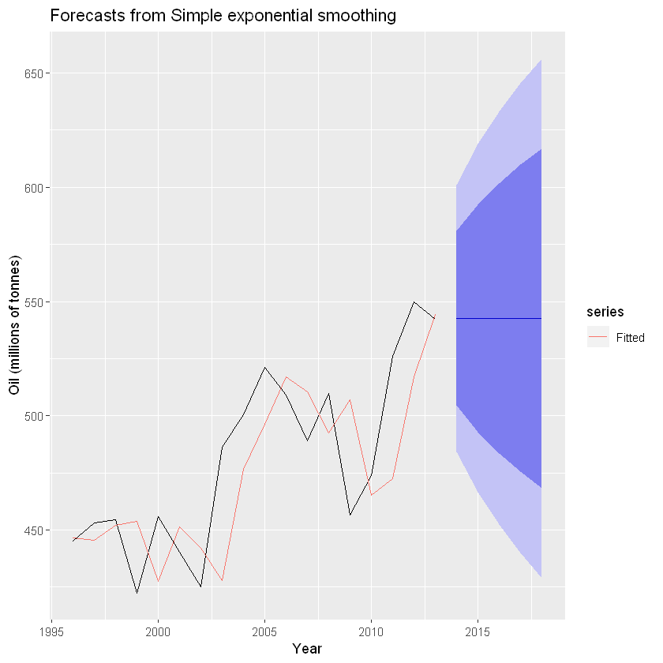

```r
# Figura 2: Suavizado exponencial simple aplicado a la producción de petróleo en Arabia Saudita (1996–2013)

autoplot(fc) +
  autolayer(fitted(fc), series="Fitted") +
  ylab("Oil (millions of tonnes)") + xlab("Year")
```

Las previsiones para el período 2014-2018 se representan en la Figura 2. También se trazan los valores ajustados de un paso adelante junto con los datos durante el período 1996-2013. El gran valor de α en este ejemplo se refleja en el gran ajuste que tiene lugar en el nivel estimado ℓt en cada momento. Un valor menor de α conduciría a cambios más pequeños con el tiempo, por lo que la serie de valores ajustados sería más uniforme.

Los intervalos de predicción que se muestran aquí se calculan utilizando los métodos descritos mas adelante. Los intervalos de predicción muestran que existe una considerable incertidumbre en los valores futuros de la producción de petróleo durante el período de pronóstico de cinco años. Por lo tanto, interpretar los pronósticos puntuales sin tener en cuenta la gran incertidumbre puede ser muy engañoso.

## 2. Método de tendencia lineal de Holt

Holt ( 1957 ) extendió el suavizado exponencial simple para permitir la predicción de datos con una tendencia. Este método implica una ecuación de pronóstico y dos ecuaciones de suavizado (una para el nivel y otra para la tendencia):

$$\begin{align*} \text{Forecast equation}&& \hat{y}_{t+h|t} &= \ell_{t} + hb_{t} \\ \text{Level equation} && \ell_{t} &= \alpha y_{t} + (1 - \alpha)(\ell_{t-1} + b_{t-1})\\ \text{Trend equation} && b_{t} &= \beta^*(\ell_{t} - \ell_{t-1}) + (1 -\beta^*)b_{t-1}, \end{align*}$$

donde ℓt denota una estimación del nivel de la serie en el momento t, bt denota una estimación de la tendencia (pendiente) de la serie en el tiempo t, α es el parámetro de suavizado para el nivel, 0≤α≤1, y β∗ es el parámetro de suavizado para la tendencia, 0≤β∗≤1.

Al igual que con el suavizado exponencial simple, la ecuación de nivel aquí muestra que ℓt es un promedio ponderado de observación yt y el pronóstico de capacitación de un paso adelante para el tiempo t, aquí dado por ℓt-1 + bt-1. La ecuación de tendencia muestra que bt es un promedio ponderado de la tendencia estimada en el tiempo t basado en ℓt - ℓt-1 y bt-1, la estimación previa de la tendencia.

La función de pronóstico ya no es flat sino tendencia. El h-step-ahead forecast es igual al último nivel estimado más h veces el último valor de tendencia estimado. Por lo tanto, los pronósticos son una función lineal de h.

**Ejemplo: pasajeros aéreos**

```r
air <- window(ausair, start=1990)
fc <- holt(air, h=5)
```

```r
fc
```

```
     Point Forecast    Lo 80    Hi 80    Lo 95    Hi 95
2017       74.60130 71.57106 77.63154 69.96695 79.23566
2018       76.70304 72.76440 80.64169 70.67941 82.72668
2019       78.80478 74.13092 83.47864 71.65673 85.95284
2020       80.90652 75.59817 86.21487 72.78810 89.02494
2021       83.00826 77.13343 88.88310 74.02348 91.99305
```

```r
fc$model
```

```
Holt's method

Call:
 holt(y = air, h = 5)

  Smoothing parameters:
    alpha = 0.8302
    beta  = 1e-04

  Initial states:
    l = 15.5715
    b = 2.1017

  sigma:  2.3645

     AIC     AICc      BIC
141.1291 143.9863 147.6083
```

En la Tabla 2 mostramos la aplicación del método de Holt a los números de pasajeros anuales para las aerolíneas australianas. Los parámetros de suavizado, α y β∗, y los valores iniciales ℓ0 y b0 se estiman minimizando el SSE para los errores de capacitación de un solo paso.

[figure not shown]

El valor muy pequeño de β∗ significa que la pendiente apenas cambia con el tiempo.

### Métodos de tendencia amortiguadas (Damped trend methods)

Los pronósticos generados por el método lineal de Holt muestran una tendencia constante (aumentando o disminuyendo) indefinidamente hacia el futuro. La evidencia empírica indica que estos métodos tienden a pronosticar en exceso, especialmente para horizontes de pronóstico más largos. Motivado por esta observación, Gardner y McKenzie ( 1985 ) introdujeron un parámetro que "amortigua" la tendencia a una línea plana en algún momento en el futuro. Los métodos que incluyen una tendencia amortiguada han demostrado ser muy exitosos, y son posiblemente los métodos individuales más populares cuando se requieren pronósticos automáticamente para muchas series.

En conjunción con los parámetros de suavizado α y β∗(con valores entre 0 y 1 como en el método de Holt), este método también incluye un parámetro de amortiguación 0<ϕ<1:

$$\begin{align*} \hat{y}_{t+h|t} &= \ell_{t} + (\phi+\phi^2 + \dots + \phi^{h})b_{t} \\ \ell_{t} &= \alpha y_{t} + (1 - \alpha)(\ell_{t-1} + \phi b_{t-1})\\ b_{t} &= \beta^*(\ell_{t} - \ell_{t-1}) + (1 -\beta^*)\phi b_{t-1} \end{align*}$$

Si ϕ=1, el método es idéntico al método lineal de Holt. Para valores entre 0 y 1, ϕ amortigua la tendencia para que se acerque a una constante en algún momento en el futuro. De hecho, los pronósticos convergen a ℓT + ϕbT/(1-ϕ) como h → ∞ para cualquier valor 0<ϕ<1. Esto significa que los pronósticos a corto plazo tienen tendencia, mientras que los pronósticos a largo plazo son constantes.

En la práctica, ϕ rara vez es inferior a 0,8, ya que la amortiguación tiene un efecto muy fuerte para valores más pequeños. Valores de ϕ cerca de 1 significará que un modelo amortiguado no puede distinguirse de un modelo no amortiguado. Por estas razones, generalmente restringimos ϕ a un mínimo de 0.8 y un máximo de 0.98.

**Ejemplo: Pasajeros aéreos (continuación)**

La Figura 3 muestra los pronósticos para los años 2017–2031 generados a partir del método de tendencia lineal de Holt y el método de tendencia amortiguada.

Figura 3: Previsión del total de pasajeros anuales de las compañías aéreas registradas en Australia (millones de pasajeros, 1990–2016). Para el método de tendencia amortiguada, ϕ=0.90.

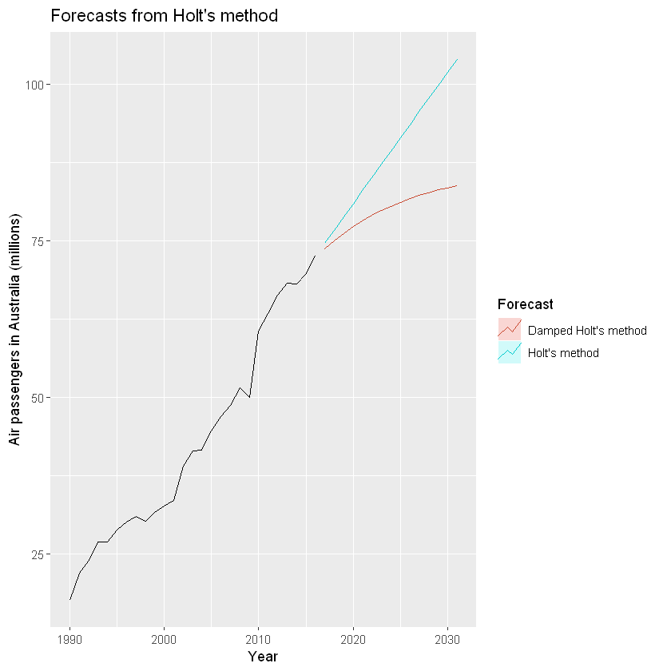

```r
fc <- holt(air, h=15)
fc2 <- holt(air, damped=TRUE, phi = 0.9, h=15)
autoplot(air) +
  autolayer(fc, series="Holt's method", PI=FALSE) +
  autolayer(fc2, series="Damped Holt's method", PI=FALSE) +
  ggtitle("Forecasts from Holt's method") + xlab("Year") +
  ylab("Air passengers in Australia (millions)") +
  guides(colour=guide_legend(title="Forecast"))
```

```r
fc2
```

```
     Point Forecast    Lo 80     Hi 80    Lo 95     Hi 95
2017       73.71036 70.35724  77.06348 68.58220  78.83852
2018       75.02175 70.30251  79.74098 67.80430  82.23919
2019       76.20199 70.01113  82.39285 66.73389  85.67010
2020       77.26421 69.53683  84.99160 65.44620  89.08223
2021       78.22021 68.91713  87.52330 63.99237  92.44806
2022       79.08061 68.18039  89.98084 62.41016  95.75107
2023       79.85497 67.34900  92.36095 60.72874  98.98121
2024       80.55190 66.44106  94.66274 58.97123 102.13257
2025       81.17913 65.47143  96.88683 57.15628 105.20198
2026       81.74364 64.45247  99.03480 55.29908 108.18820
2027       82.25170 63.39448 101.10891 53.41207 111.09132
2028       82.70895 62.30612 103.11178 51.50551 113.91238
2029       83.12047 61.19467 105.04628 49.58785 116.65310
2030       83.49085 60.06628 106.91541 47.66607 119.31563
2031       83.82418 58.92614 108.72223 45.74592 121.90245
```

```r
fc2$model
```

```
Damped Holt's method

Call:
 holt(y = air, h = 15, damped = TRUE, phi = 0.9)

  Smoothing parameters:
    alpha = 0.763
    beta  = 0.2526
    phi   = 0.9

  Initial states:
    l = 14.5766
    b = 3.7517

  sigma:  2.6165

     AIC     AICc      BIC
145.3965 148.2536 151.8757
```

Hemos establecido el parámetro de amortiguación en un número relativamente bajo (ϕ=0.90) para exagerar el efecto de la amortiguación para la comparación. Por lo general, estimaríamos ϕ junto con los otros parámetros. También hemos utilizado un horizonte de pronóstico bastante grande ( h=15) para resaltar la diferencia entre una tendencia amortiguada y una tendencia lineal. En la práctica, normalmente no queremos pronosticar tantos años por delante con solo 27 años de datos.

**Ejemplo: ovejas en Asia**

En este ejemplo, comparamos el rendimiento de pronóstico de los tres métodos de suavizado exponencial que hemos considerado hasta ahora al pronosticar la población de ganado ovino en Asia. Los datos abarcan el período 1961–2007 y se muestran en la Figura 4.

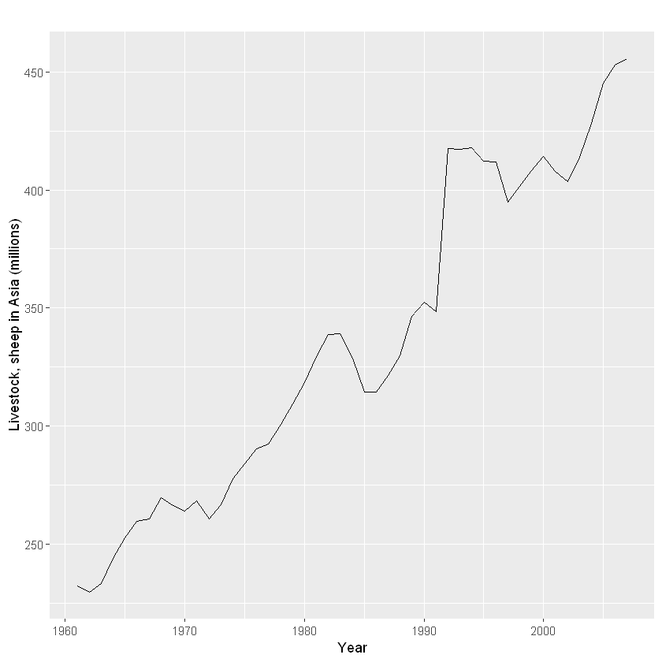

```r
autoplot(livestock) +
  xlab("Year") + ylab("Livestock, sheep in Asia (millions)")
```

Utilizaremos la validación cruzada de series temporales para comparar la precisión del pronóstico en un solo paso de los tres métodos.

```r
e1 <- tsCV(livestock, ses, h=1)
e2 <- tsCV(livestock, holt, h=1)
e3 <- tsCV(livestock, holt, damped=TRUE, h=1)

# Compare MSE:
mean(e1^2, na.rm=TRUE)
```

```
#> [1] 178.3
```

```r
mean(e2^2, na.rm=TRUE)
```

```
#> [1] 173.4
```

```r
mean(e3^2, na.rm=TRUE)
```

```
#> [1] 162.6
```

```r
# Compare MAE:
mean(abs(e1), na.rm=TRUE)
```

```
#> [1] 8.532
```

```r
mean(abs(e2), na.rm=TRUE)
```

```
#> [1] 8.803
```

```r
mean(abs(e3), na.rm=TRUE)
```

```
#> [1] 8.024
```

El método amortiguado de Holt es mejor si compara los valores de MAE o MSE. Por lo tanto, procederemos a utilizar el método de Holt amortiguado y lo aplicaremos a todo el conjunto de datos para obtener pronósticos para años futuros.

```r
fc <- holt(livestock, damped=TRUE)
fc$model
```

```
Damped Holt's method

Call:
 holt(y = livestock, damped = TRUE)

  Smoothing parameters:
    alpha = 0.9999
    beta  = 3e-04
    phi   = 0.9798

  Initial states:
    l = 223.35
    b = 6.9046

  sigma:  12.8435

     AIC     AICc      BIC
427.6370 429.7370 438.7379
```

Se estima que el parámetro de suavizado para la pendiente es esencialmente cero, lo que indica que la tendencia no cambia con el tiempo. El valor de α está muy cerca de uno, lo que demuestra que el nivel reacciona fuertemente a cada nueva observación.

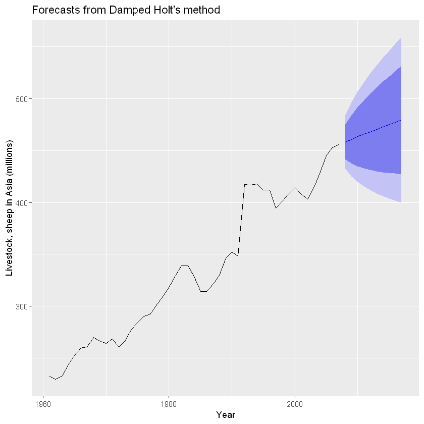

```r
autoplot(fc) +
  xlab("Year") + ylab("Livestock, sheep in Asia (millions)")
```

Las previsiones resultantes parecen razonables con una tendencia creciente y con intervalos de predicción relativamente amplios que reflejan la variación en los datos históricos. Los intervalos de predicción se calculan utilizando los métodos descritos mas adelante.

En este ejemplo, el proceso de selección de un método fue relativamente fácil ya que las comparaciones de MSE y MAE sugirieron el mismo método (amortiguado por Holt). Sin embargo, a veces diferentes medidas de precisión sugerirán diferentes métodos de pronóstico, y luego se requiere una decisión sobre qué método de pronóstico preferimos usar. Como las tareas de pronóstico pueden variar en muchas dimensiones (longitud del horizonte de pronóstico, tamaño del conjunto de prueba, medidas de error de pronóstico, frecuencia de datos, etc.), es poco probable que un método sea mejor que todos los demás para todos los escenarios de pronóstico. Lo que requerimos de un método de pronóstico son pronósticos consistentemente razonables, y estos deben evaluarse con frecuencia en función de la tarea en cuestión.

## 3. Método estacional de Holt-Winters

Holt ( 1957 ) y Winters ( 1960 ) extendieron el método de Holt para capturar la estacionalidad. El método estacional Holt-Winters comprende la ecuación de pronóstico y tres ecuaciones de suavizado, una para el nivel ℓt, uno para la tendencia bt, y uno para el componente estacional st, con los correspondientes parámetros de suavizado α, β∗ y γ. Usamos m para denotar la frecuencia de la estacionalidad, es decir, el número de estaciones en un año. Por ejemplo, para datos trimestrales m=4 y para datos mensuales m=12.

Hay dos variaciones de este método que difieren en la naturaleza del componente estacional. Se prefiere el **método aditivo** cuando las **variaciones estacionales son aproximadamente constantes a través de la serie**, mientras que el **método multiplicativo** se prefiere cuando las **variaciones estacionales cambian proporcionalmente al nivel de la serie**.

Con el **método aditivo**, el componente estacional se expresa en términos absolutos en la escala de la serie observada, y en la ecuación de nivel, la serie se ajusta estacionalmente restando el componente estacional. Dentro de cada año, el componente estacional sumará aproximadamente cero.

### Método aditivo de Holt-Winters

La forma del componente para el método aditivo es:

$$\begin{align*} \hat{y}_{t+h|t} &= \ell_{t} + hb_{t} + s_{t+h-m(k+1)} \\ \ell_{t} &= \alpha(y_{t} - s_{t-m}) + (1 - \alpha)(\ell_{t-1} + b_{t-1})\\ b_{t} &= \beta^*(\ell_{t} - \ell_{t-1}) + (1 - \beta^*)b_{t-1}\\ s_{t} &= \gamma (y_{t}-\ell_{t-1}-b_{t-1}) + (1-\gamma)s_{t-m}, \end{align*}$$

donde k es la parte entera de (h-1)/m, lo que garantiza que las estimaciones de los índices estacionales utilizados para pronosticar procedan del último año de la muestra. La ecuación de nivel muestra un promedio ponderado entre la observación ajustada estacionalmente (yt-st-m) y el pronóstico no estacional (ℓt-1+bt-1) por tiempo t. La ecuación de tendencia es idéntica al método lineal de Holt. La ecuación estacional muestra un promedio ponderado entre el índice estacional actual, (yt-ℓt-1-bt-1), y el índice estacional de la misma temporada del año pasado (es decir, m períodos de tiempo atrás).

La ecuación para el componente estacional a menudo se expresa como:

Si sustituimos ℓt a partir de la ecuación de suavizado para el nivel del componente de arriba, obtenemos:

$$s_{t} = \gamma^*(1-\alpha) (y_{t}-\ell_{t-1}-b_{t-1})+ [1-\gamma^*(1-\alpha)]s_{t-m}$$

### Método multiplicativo de Holt-Winters

La forma del componente para el método multiplicativo es:

$$\begin{align*} \hat{y}_{t+h|t} &= (\ell_{t} + hb_{t})s_{t+h-m(k+1)} \\ \ell_{t} &= \alpha \frac{y_{t}}{s_{t-m}} + (1 - \alpha)(\ell_{t-1} + b_{t-1})\\ b_{t} &= \beta^*(\ell_{t}-\ell_{t-1}) + (1 - \beta^*)b_{t-1} \\ s_{t} &= \gamma \frac{y_{t}}{(\ell_{t-1} + b_{t-1})} + (1 - \gamma)s_{t-m} \end{align*}$$

**Ejemplo: noches de turistas internacionales en Australia**

Aplicamos el método de Holt-Winters con estacionalidad aditiva y multiplicativa para pronosticar las noches de visitantes trimestrales en Australia que pasan los turistas internacionales. La figura 6 muestra los datos de 2005 y las previsiones para 2016-2017. Los datos muestran un patrón estacional, con picos observados en el trimestre de marzo de cada año, correspondiente al verano australiano.

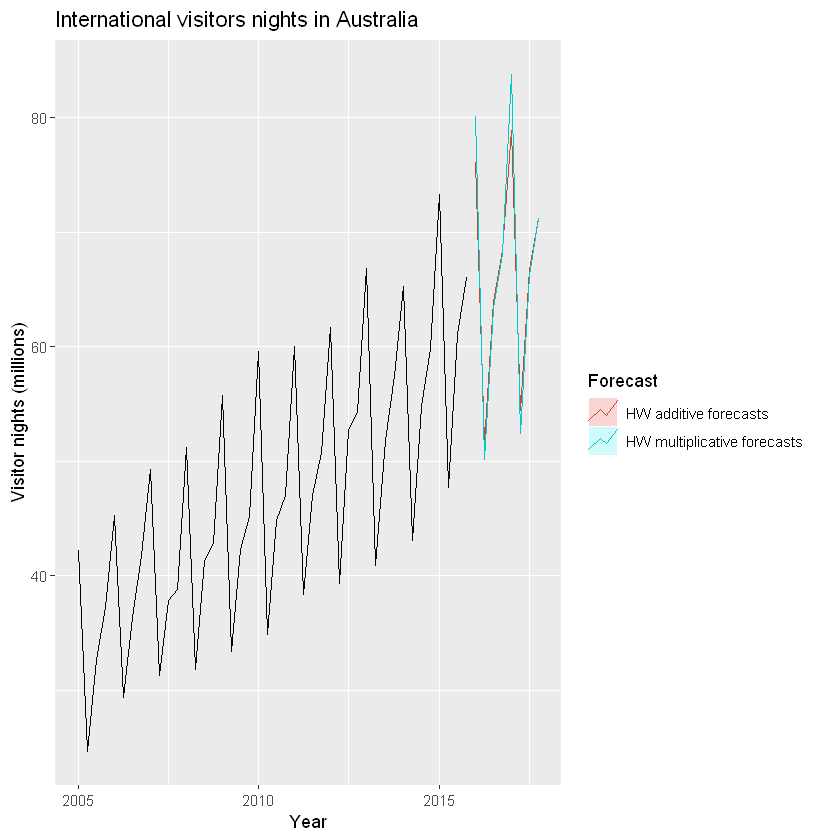

```r
#FIGURA 6

aust <- window(austourists,start=2005)
fit1 <- hw(aust,seasonal="additive")
fit2 <- hw(aust,seasonal="multiplicative")
autoplot(aust) +
  autolayer(fit1, series="HW additive forecasts", PI=FALSE) +
  autolayer(fit2, series="HW multiplicative forecasts",
    PI=FALSE) +
  xlab("Year") +
  ylab("Visitor nights (millions)") +
  ggtitle("International visitors nights in Australia") +
  guides(colour=guide_legend(title="Forecast"))
```

```r
fit1$model
```

```
Holt-Winters' additive method

Call:
 hw(y = aust, seasonal = "additive")

  Smoothing parameters:
    alpha = 0.3063
    beta  = 1e-04
    gamma = 0.4263

  Initial states:
    l = 32.2597
    b = 0.7014
    s = 1.3106 -1.6935 -9.3132 9.6962

  sigma:  1.9494

     AIC     AICc      BIC
234.4171 239.7112 250.4748
```

```r
accuracy(fit1)
```

|  | ME | RMSE | MAE | MPE | MAPE | MASE | ACF1 |
| --- | --- | --- | --- | --- | --- | --- | --- |
| Training set | 0.008115785 | 1.763305 | 1.374062 | -0.2860248 | 2.973922 | 0.4502579 | -0.06272507 |

```r
fit1
```

```
        Point Forecast    Lo 80    Hi 80    Lo 95    Hi 95
2016 Q1       76.09837 73.60011 78.59664 72.27761 79.91914
2016 Q2       51.60333 48.99039 54.21626 47.60718 55.59947
2016 Q3       63.96867 61.24582 66.69153 59.80443 68.13292
2016 Q4       68.37170 65.54313 71.20027 64.04578 72.69762
2017 Q1       78.90404 75.53440 82.27369 73.75061 84.05747
2017 Q2       54.40899 50.95325 57.86473 49.12389 59.69409
2017 Q3       66.77434 63.23454 70.31414 61.36069 72.18799
2017 Q4       71.17737 67.55541 74.79933 65.63806 76.71667
```

```r
fit2$model
```

```
Holt-Winters' multiplicative method

Call:
 hw(y = aust, seasonal = "multiplicative")

  Smoothing parameters:
    alpha = 0.4406
    beta  = 0.0134
    gamma = 0.0023

  Initial states:
    l = 32.4875
    b = 0.6974
    s = 1.0237 0.9618 0.7704 1.2442

  sigma:  0.0367

     AIC     AICc      BIC
221.1313 226.4254 237.1890
```

```r
accuracy(fit2)
```

|  | ME | RMSE | MAE | MPE | MAPE | MASE | ACF1 |
| --- | --- | --- | --- | --- | --- | --- | --- |
| Training set | 0.09206228 | 1.575631 | 1.25496 | -0.0006505546 | 2.70539 | 0.4112302 | -0.07955726 |

```r
fit2
```

```
        Point Forecast    Lo 80    Hi 80    Lo 95    Hi 95
2016 Q1       80.08894 76.31865 83.85922 74.32278 85.85509
2016 Q2       50.15482 47.56655 52.74309 46.19640 54.11324
2016 Q3       63.34322 59.80143 66.88502 57.92652 68.75993
2016 Q4       68.17810 64.08399 72.27221 61.91670 74.43950
2017 Q1       83.80112 78.43079 89.17146 75.58790 92.01434
2017 Q2       52.45291 48.88795 56.01787 47.00077 57.90504
2017 Q3       66.21274 61.46194 70.96353 58.94702 73.47845
2017 Q4       71.23205 65.85721 76.60690 63.01194 79.45217
```

Debido a que ambos métodos tienen exactamente el mismo número de parámetros para estimar, podemos comparar el RMSE de entrenamiento de ambos modelos. En este caso, el método con estacionalidad multiplicativa se ajusta mejor a los datos. Esto era de esperarse, ya que el gráfico de tiempo muestra que la variación estacional en los datos aumenta a medida que aumenta el nivel de la serie. Esto también se refleja en los dos conjuntos de pronósticos; los pronósticos generados por el método con la estacionalidad multiplicativa muestran una variación estacional mayor y creciente a medida que aumenta el nivel de los pronósticos en comparación con los pronósticos generados por el método con estacionalidad aditiva.

Los estados estimados para ambos modelos se representan en la figura 7 . El pequeño valor de γ para el modelo multiplicativo significa que el componente estacional apenas cambia con el tiempo. El pequeño valor de β∗ para el modelo aditivo significa que el componente de pendiente apenas cambia con el tiempo (verifique la escala vertical). El tamaño creciente del componente estacional para el modelo aditivo sugiere que el modelo es menos apropiado que el modelo multiplicativo.

FIGURA 7:

[figure not shown]

### Método amortiguado de Holt-Winters

La amortiguación es posible con los métodos de Holt-Winters aditivos y multiplicativos. Un método que a menudo proporciona pronósticos precisos y robustos para datos estacionales es el método Holt-Winters con una tendencia amortiguada y una estacionalidad multiplicativa:

$$\begin{align*} \hat{y}_{t+h|t} &= \left[\ell_{t} + (\phi+\phi^2 + \dots + \phi^{h})b_{t}\right]s_{t+h-m(k+1)}. \\ \ell_{t} &= \alpha(y_{t} / s_{t-m}) + (1 - \alpha)(\ell_{t-1} + \phi b_{t-1})\\ b_{t} &= \beta^*(\ell_{t} - \ell_{t-1}) + (1 - \beta^*)\phi b_{t-1} \\ s_{t} &= \gamma \frac{y_{t}}{(\ell_{t-1} + \phi b_{t-1})} + (1 - \gamma)s_{t-m}. \end{align*}$$

```r
hw(y, damped=TRUE, seasonal="multiplicative")
```

**Ejemplo: método Holt-Winters con datos diarios**

El método Holt-Winters también se puede utilizar para el tipo de datos diarios, donde el período estacional es m=7 y la unidad de tiempo adecuada para h es en dias. Aquí, generamos pronósticos diarios para las últimas cinco semanas para los datos hyndsight, que contienen las páginas vistas diarias en el blog de Hyndsight para un año a partir del 30 de abril de 2014.

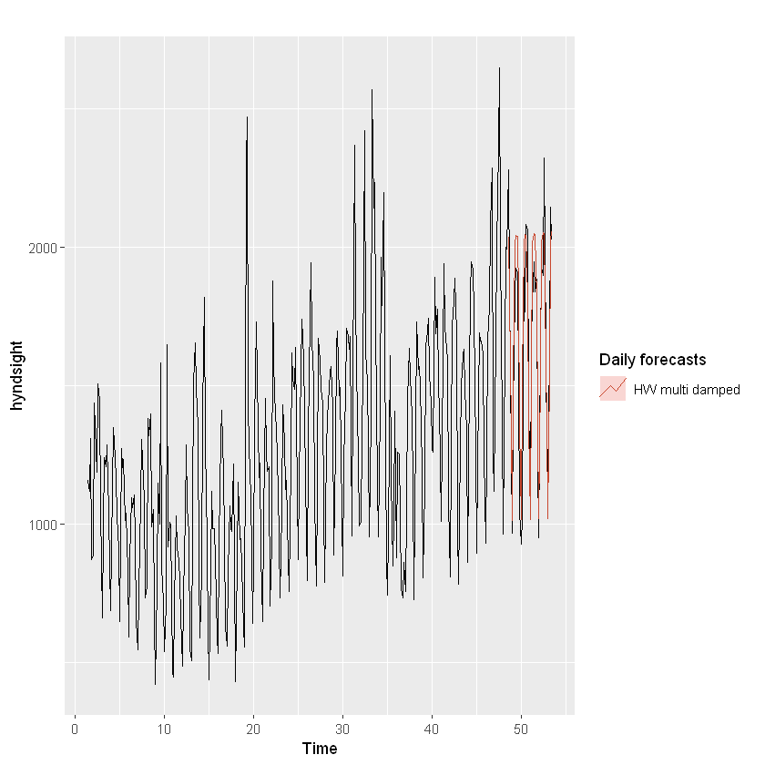

```r
#FIGURA 8

fc <- hw(subset(hyndsight,end=length(hyndsight)-35),
         damped = TRUE, seasonal="multiplicative", h=35)
autoplot(hyndsight) +
  autolayer(fc, series="HW multi damped", PI=FALSE)+
  guides(colour=guide_legend(title="Daily forecasts"))
```

Claramente, el modelo ha identificado el patrón estacional semanal y la tendencia creciente al final de los datos, y los pronósticos coinciden estrechamente con los datos de la prueba.

## 4. Taxonomía de métodos de suavizado exponencial

Los métodos de suavizado exponencial no están restringidos a los que hemos presentado hasta ahora. Al considerar las variaciones en las combinaciones de tendencia y componentes estacionales, son posibles nueve métodos de suavizado exponencial, enumerados en la Tabla 5.

Cada método está etiquetado por un par de letras (T, S) que definen el tipo de componentes 'Tendencia' y 'Estacional'. Por ejemplo, (A, M) es el método con una tendencia aditiva y estacionalidad multiplicativa; (A d, N) es el método con tendencia amortiguada y sin estacionalidad.

**Tabla 5: Clasificación bidireccional de los métodos de suavizado exponencial**

[figure not shown]

**Tabla 6**: Fórmulas para cálculos recursivos y pronósticos puntuales. En cada caso, ℓt denota el nivel de serie en el tiempo t, bt denota la pendiente en el tiempo t, st denota el componente estacional de la serie en el tiempo t y m denota el número de estaciones en un año; α, β∗, γ y ϕ son parámetros de suavizado, $\phi_h = \phi+\phi^2+\dots+\phi^{h}$ y k son la parte entera de (h-1)/m.

[figure not shown]

## 5. Innovaciones de modelos de espacio de estado para suavizado exponencial

A continuacion, estudiamos los **modelos estadísticos** que subyacen a los métodos de suavizado exponencial que hemos considerado hasta ahora. Los métodos de suavizado exponencial presentados en la Tabla 6 son algoritmos que generan pronósticos puntuales.

Los **modelos estadísticos** de a continuación generan los mismos pronósticos puntuales, pero también pueden generar intervalos de predicción.

Un **modelo estadístico** es un proceso de generación de datos estocástico (o aleatorio) que puede producir una distribución de pronóstico completa. También describiremos cómo usar los criterios de selección de modelo para elegir el modelo de manera objetiva.

Cada modelo consta de una **ecuación de medición** que describe los datos observados y algunas ecuaciones de estado que describen cómo los componentes o estados no observados (nivel, tendencia, estacional) cambian con el tiempo. Por lo tanto, estos se conocen como **modelos de espacio de estado**.

Para cada método existen dos modelos: uno con **errores aditivos** y otro con **errores multiplicativos**. Los pronósticos puntuales producidos por los modelos son idénticos si usan los mismos valores de parámetros de suavizado. Sin embargo, generarán diferentes intervalos de predicción.

Para distinguir entre un modelo con errores aditivos y uno con errores multiplicativos (y también para distinguir los modelos de los métodos), agregamos una tercera letra a la clasificación de la Tabla 5. Etiquetamos cada modelo de espacio de estado como ETS ( ) para (Error, Tendencia, Estacional). Las posibilidades para cada componente son: Error A, M , Tendencia N, A, A y estacional N, A, M

### ETS (A, N, N): suavizado exponencial simple con errores aditivos

### ETS(M,N,N): suavizado exponencial simple con errores multiplicativos

### ETS (A, A, N): método lineal de Holt con errores aditivos

### ETS (M, A, N): método lineal de Holt con errores multiplicativos

### Otros modelos de ETS

[figure not shown]

## 6. Estimación y selección de modelo

Una alternativa a la estimación de los parámetros al minimizar la suma de los errores al cuadrado es maximizar la "probabilidad". La probabilidad de que los datos surjan del modelo especificado. Por lo tanto, una gran probabilidad se asocia con un buen modelo. Para un modelo de error aditivo, maximizar la probabilidad (suponiendo errores distribuidos normalmente) da los mismos resultados que minimizar la suma de los errores al cuadrado. Sin embargo, se obtendrán resultados diferentes para los modelos de error multiplicativo.

Los posibles valores que pueden tomar los parámetros de suavizado están restringidos. Tradicionalmente, los parámetros se han limitado a estar entre 0 y 1 para que las ecuaciones puedan interpretarse como promedios ponderados.

Otra forma de ver los parámetros es a través de una consideración de las propiedades matemáticas de los modelos de espacio de estados. Los parámetros están restringidos para evitar que las observaciones en el pasado distante tengan un efecto continuo en los pronósticos actuales. Esto lleva a algunas restricciones de admisibilidad en los parámetros, que generalmente son (pero no siempre) menos restrictivas que la región de restricciones tradicionales (Hyndman et al., 2008 , p. Ch10) .

### Selección de modelo

Una gran ventaja del ETS es que los criterios de información se pueden utilizar para la selección del modelo. El AIC, AICc.

Para los modelos ETS, el Criterio de información de Akaike (AIC) se define como:

$$\text{AIC} = -2\log(L) + 2k$$

donde L es la probabilidad del modelo y k es el número total de parámetros y estados iniciales que se han estimado (incluida la varianza residual)

El AIC corregido por sesgo de muestra pequeña (AIC c ) se define como :

$$\text{AIC}_{\text{c}} = \text{AIC} + \frac{2k(k+1)}{T-k-1}$$

y el Criterio de Información Bayesiano (BIC) es:

$$\text{BIC} = \text{AIC} + k[\log(T)-2]$$

Tres de las combinaciones de (Error, Tendencia, Estacional) pueden conducir a dificultades numéricas. Específicamente, los modelos que pueden causar tales inestabilidades son ETS (A, N, M), ETS (A, A, M) y ETS (A, Ad , M), debido a la división por valores potencialmente cercanos a cero en el ecuaciones de estado, Normalmente no consideramos estas combinaciones particulares al seleccionar un modelo.

Los modelos con errores multiplicativos son útiles cuando los datos son estrictamente positivos, pero no son numéricamente estables cuando los datos contienen ceros o valores negativos. Por lo tanto, los modelos de error multiplicativo no se considerarán si la serie temporal no es estrictamente positiva. En ese caso, solo se aplicarán los seis modelos totalmente aditivos.

### La función ets() en R

Los modelos se pueden estimar en R usando la función ets() en el paquete de forecast. A diferencia de las funciones ses(), holt()y hw(), la función ets() no produce pronósticos. Más bien, estima los parámetros del modelo y devuelve información sobre el modelo ajustado. Por defecto, utiliza el AICc para seleccionar un modelo apropiado, aunque se pueden seleccionar otros criterios de información.

El código R a continuación muestra los argumentos más importantes que puede tomar esta función y sus valores predeterminados. Si solo se especifica la serie temporal y todos los demás argumentos se dejan en sus valores predeterminados, se seleccionará automáticamente un modelo apropiado. Explicamos los argumentos a continuación.

```r
ets(y, model="ZZZ", damped=NULL, alpha=NULL, beta=NULL,
    gamma=NULL, phi=NULL, lambda=NULL, biasadj=FALSE,
    additive.only=FALSE, restrict=TRUE,
    allow.multiplicative.trend=FALSE)
```

- **y** = La serie temporal a pronosticar.
- **model** = Un código de tres letras que indica el modelo a estimar utilizando la clasificación y notación ETS. Las entradas posibles son "N" para ninguno, "A" para aditivo, "M" para multiplicativo o "Z" para selección automática. Si alguna de las entradas se deja como "Z", este componente se selecciona de acuerdo con el criterio de información. El valor predeterminado de ZZZ asegura que todos los componentes se seleccionen utilizando el criterio de información.
- **damped** = Si damped=TRUE, entonces se utilizará una tendencia amortiguada (A o M). Si damped=FALSE, entonces se utilizará una tendencia no amortiguada. Si damped=NULL(el valor predeterminado), se seleccionará una tendencia amortiguada o no amortiguada, según el modelo que tenga el valor más pequeño para el criterio de información.
- **alpha, beta, gamma, phi** = Los valores de los parámetros de suavizado se pueden especificar utilizando estos argumentos. Si se establecen en NULL(la configuración predeterminada para cada uno de ellos), se estiman los parámetros.
- **lambda** = Parámetro de transformación Box-Cox. Se ignorará si lambda=NULL(el valor predeterminado). De lo contrario, la serie temporal se transformará antes de que se calcule el modelo. Cuando lambda no es NULL, additive.only se establece en TRUE.
- **biasadj** = Si TRUE y lambda no es así NULL, los valores ajustados transformados y los pronósticos se ajustarán al sesgo.
- **additive.only** = Solo se considerarán modelos con componentes aditivos si additive.only=TRUE. De lo contrario, se considerarán todos los modelos.
- **restrict** = Si restrict=TRUE(el valor predeterminado), los modelos que causan dificultades numéricas no se consideran en la selección del modelo.
- **allow.multiplicative.trend** = Los modelos de tendencia multiplicativa también están disponibles. Establezca este argumento en TRUE para permitir que se consideren estos modelos.

## Objetos ets

La función ets() devolverá un objeto de clase ets. Hay muchas funciones R diseñadas para facilitar el trabajo con objetos ets. Algunos de ellos se describen a continuación.

**coef()** devuelve todos los parámetros ajustados.

**accuracy()** devuelve medidas de precisión calculadas en los datos de entrenamiento.

**summary()** imprime información resumida sobre el modelo ajustado.

**autoplot() y plot()** producir gráficos de tiempo de los componentes.

**residuals()** devuelve residuos del modelo estimado.

**fitted()** devuelve pronósticos de un paso para los datos de entrenamiento.

**simulate()** simulará futuros caminos de muestra del modelo ajustado.

**forecast()** calcula pronósticos puntuales e intervalos de predicción-

**Ejemplo: noches de turistas internacionales en Australia**

```r
aust <- window(austourists, start=2005)
```

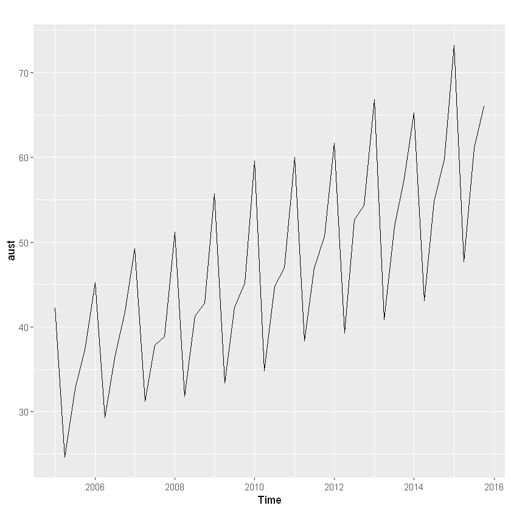

```r
autoplot(aust)
```

```r
fit <- ets(aust)
summary(fit)
```

```
ETS(M,A,M)

Call:
 ets(y = aust)

  Smoothing parameters:
    alpha = 0.1908
    beta  = 0.0392
    gamma = 2e-04

  Initial states:
    l = 32.3679
    b = 0.9281
    s = 1.0218 0.9628 0.7683 1.2471

  sigma:  0.0383

     AIC     AICc      BIC
224.8628 230.1569 240.9205

Training set error measures:
                     ME     RMSE     MAE        MPE     MAPE     MASE      ACF1
Training set 0.04836907 1.670893 1.24954 -0.1845609 2.692849 0.409454 0.2005962
```

El modelo seleccionado es ETS (M, A, M): $$\begin{align*} y_{t} &= (\ell_{t-1} + b_{t-1})s_{t-m}(1 + \varepsilon_t)\\ \ell_t &= (\ell_{t-1} + b_{t-1})(1 + \alpha \varepsilon_t)\\ b_t &=b_{t-1} + \beta(\ell_{t-1} + b_{t-1})\varepsilon_t\\ s_t &= s_{t-m}(1+ \gamma \varepsilon_t). \end{align*}$$

El modelo ETS (M, A, M) dará pronósticos de puntos diferentes al método multiplicativo de Holt-Winters, porque los parámetros se han estimado de manera diferente. Con la función ets(), el método de estimación predeterminado es la probabilidad máxima en lugar de la suma mínima de cuadrados.

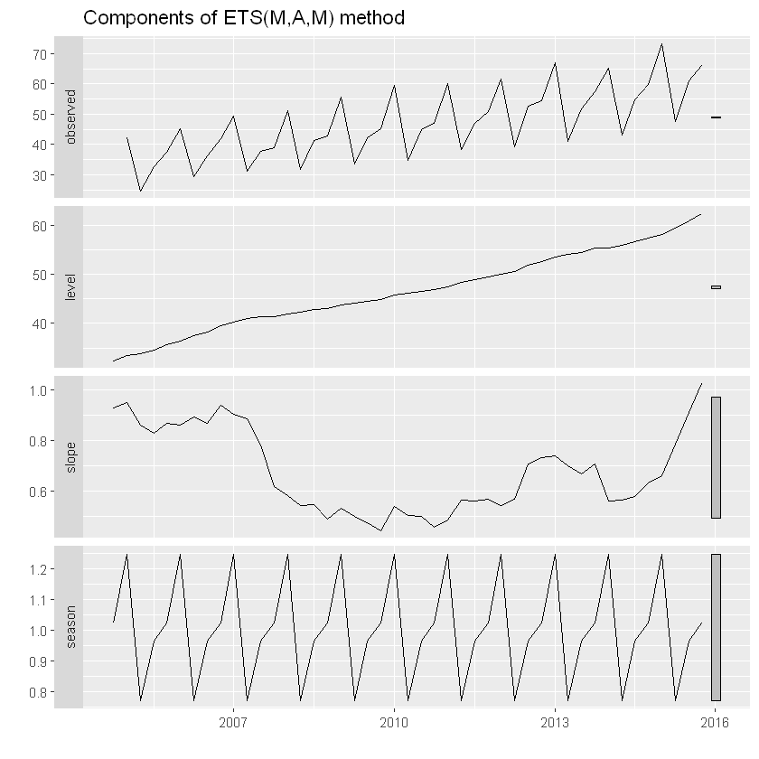

```r
autoplot(fit)
```

Debido a que este modelo tiene errores multiplicativos, los residuos no son equivalentes a los errores de entrenamiento de un paso. Los residuos están dadas por εt , Mientras que los errores de entrenamiento de un solo paso se definen como $y_t - \hat{y}_{t|t-1}$. Podemos obtener ambos usando residuals().

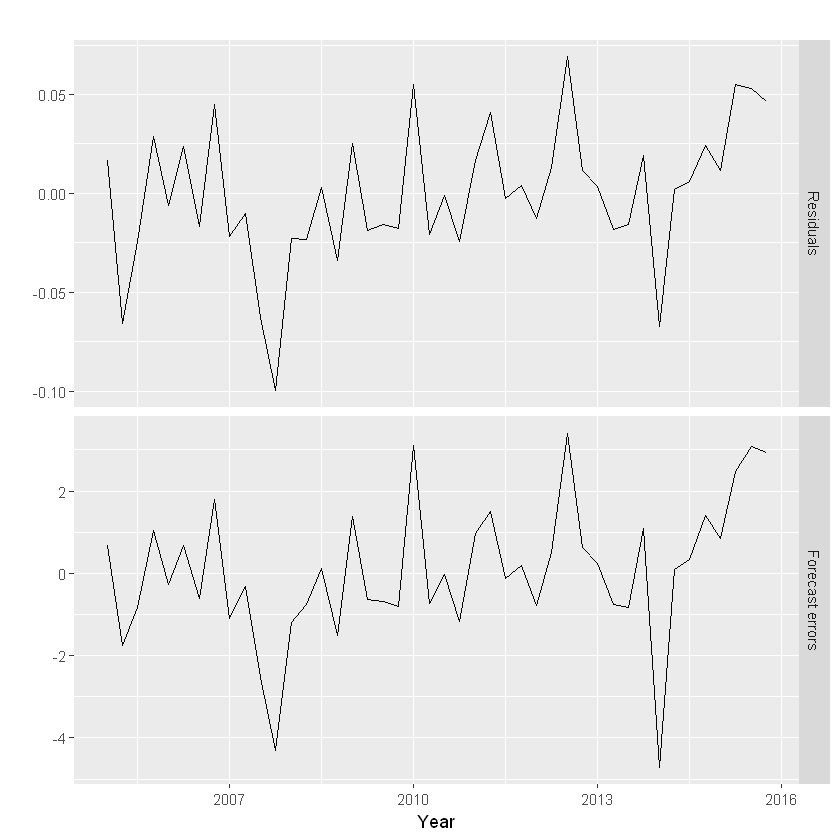

```r
cbind('Residuals' = residuals(fit),
      'Forecast errors' = residuals(fit,type='response')) %>%
  autoplot(facet=TRUE) + xlab("Year") + ylab("")
```

El argumento type se usa en la función residuals() para distinguir entre residuos y errores de pronóstico. El valor predeterminado es el type='innovation' que da residuos regulares.

Los pronósticos puntuales se obtienen de los modelos iterando las ecuaciones para $t=T+1,\dots,T+h$ y y configurando todo εt=0 para t>T.

For example, for model ETS(M,A,N) $y_{T+1} = (\ell_T + b_T )(1+ \varepsilon_{T+1})$ Por lo tanto $\hat{y}_{T+1|T}=\ell_{T}+b_{T}$

Similar,

$\begin{align*} y_{T+2} &= (\ell_{T+1} + b_{T+1})(1 + \varepsilon_{T+1})\\ &= \left[ (\ell_T + b_T) (1+ \alpha\varepsilon_{T+1}) + b_T + \beta (\ell_T + b_T)\varepsilon_{T+1} \right] ( 1 + \varepsilon_{T+1}). \end{align*}$

Por lo tanto, $\hat{y}_{T+2|T}= \ell_{T}+2b_{T}$

Estos pronósticos son idénticos a los pronósticos del método lineal de Holt, y también a los del modelo ETS (A, A, N). Por lo tanto, los pronósticos puntuales obtenidos del método y de los dos modelos que subyacen al método son idénticos (suponiendo que se usen los mismos valores de parámetros).

Los pronósticos puntuales de ETS son iguales a las medianas de las distribuciones de pronósticos. Para los modelos con solo componentes aditivos, las distribuciones de pronóstico son normales, por lo que las medianas y las medias son iguales. Para los modelos ETS con errores multiplicativos, o con estacionalidad multiplicativa, los pronósticos puntuales no serán iguales a las medias de las distribuciones pronosticadas.

Para obtener pronósticos de un modelo ETS, utilizamos forecast().

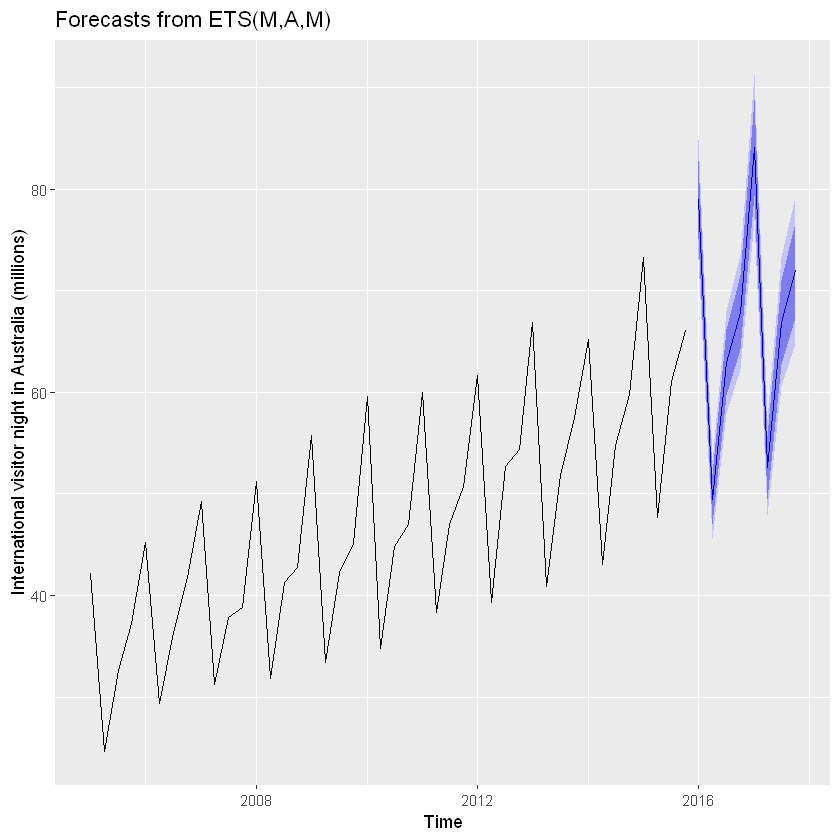

```r
fit %>% forecast(h=8) %>%
  autoplot() +
  ylab("International visitor night in Australia (millions)")
```

```r
summary(fit %>% forecast(h=8))
```

```
Forecast method: ETS(M,A,M)

Model Information:
ETS(M,A,M)

Call:
 ets(y = aust)

  Smoothing parameters:
    alpha = 0.1908
    beta  = 0.0392
    gamma = 2e-04

  Initial states:
    l = 32.3679
    b = 0.9281
    s = 1.0218 0.9628 0.7683 1.2471

  sigma:  0.0383

     AIC     AICc      BIC
224.8628 230.1569 240.9205

Error measures:
                     ME     RMSE     MAE        MPE     MAPE     MASE      ACF1
Training set 0.04836907 1.670893 1.24954 -0.1845609 2.692849 0.409454 0.2005962

Forecasts:
        Point Forecast    Lo 80    Hi 80    Lo 95    Hi 95
2016 Q1       78.99701 75.12395 82.87007 73.07368 84.92034
2016 Q2       49.45352 46.96750 51.93955 45.65148 53.25557
2016 Q3       62.96068 59.69471 66.22665 57.96581 67.95555
2016 Q4       67.86576 64.21150 71.52002 62.27705 73.45447
2017 Q1       84.09844 79.37334 88.82353 76.87203 91.32484
2017 Q2       52.59637 49.49981 55.69293 47.86059 57.33214
2017 Q3       66.89935 62.75862 71.04007 60.56666 73.23204
2017 Q4       72.04590 67.34675 76.74505 64.85917 79.23263
```

A continuación muestra los posibles argumentos que toma esta función cuando se aplica a un modelo ETS. Explicamos cada uno de los argumentos a continuación.

```r
forecast(object, h=ifelse(object$m>1, 2*object$m, 10),
level=c(80,95), fan=FALSE, simulate=FALSE, bootstrap=FALSE,
npaths=5000, PI=TRUE, lambda=object$lambda, biasadj=NULL, ...)
```

**object** El objeto devuelto por la función ets().

h El horizonte de pronóstico: el número de períodos a pronosticar.

level El nivel de confianza para los intervalos de predicción.

fan Si fan=TRUE, level=seq(50,99,by=1). Esto es adecuado para trazados de abanico

simulate Si simulate=TRUE, los intervalos de predicción se producen por simulación en lugar de usar fórmulas algebraicas. La simulación también se usará (incluso si simulate=FALSE) donde no hay fórmulas algebraicas disponibles para el modelo en particular.

bootstrap Si bootstrap=TRUEy simulate=TRUE, entonces los intervalos de predicción simulados usan errores re-muestreados en lugar de errores distribuidos normalmente.

npaths El número de rutas de muestra utilizadas en el cálculo de intervalos de predicción simulados.

PI Si PI=TRUE, entonces se producen intervalos de predicción; de lo contrario solo se calculan los pronósticos puntuales.

lambda El parámetro de transformación Box-Cox. Esto se ignora si lambda=NULL. De lo contrario, los pronósticos se transforman a través de una transformación inversa de Box-Cox.

biasadj Si lambdano es así NULL, los pronósticos transformados hacia atrás (y los intervalos de predicción) se ajustan al sesgo.

# ANEXO

### Método Naive

Para pronósticos Naive, simplemente establecemos que todos los pronósticos sean el valor de la última observación. Es decir, Este método funciona notablemente bien para muchas series de tiempo económicas y financieras.

$$\hat{y}_{T+h|T} = y_{T}$$

Debido a que un pronóstico naive es óptimo cuando los datos siguen una **random walk**, estos también se denominan **random walk forecasts**.

```r
# y contains the time series
# h is the forecast horizon

naive(y, h)
rwf(y, h) # Equivalent alternative
```

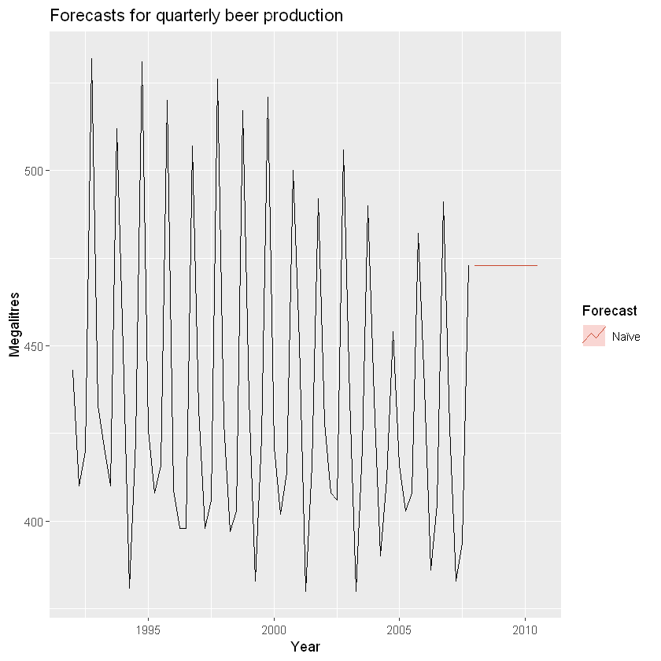

```r
# Set training data from 1992 to 2007
beer2 <- window(ausbeer,start=1992,end=c(2007,4))
# Plot some forecasts
autoplot(beer2) +
  autolayer(naive(beer2, h=11),
            series="Naïve", PI=FALSE) +
    ggtitle("Forecasts for quarterly beer production") +
  xlab("Year") + ylab("Megalitres") +
  guides(colour=guide_legend(title="Forecast"))
```

Los métodos no estacionales se aplican a una serie de 200 días del precio de cierre de acciones diario de Google.

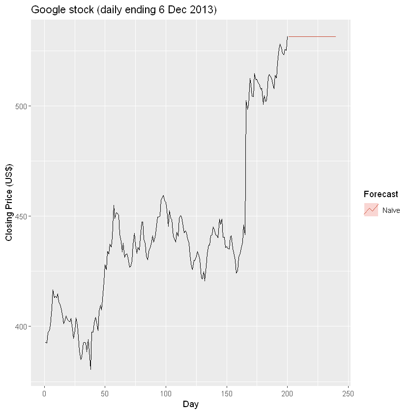

```r
autoplot(goog200) +
  autolayer(rwf(goog200, h=40),
    series="Naïve", PI=FALSE) +
  ggtitle("Google stock (daily ending 6 Dec 2013)") +
  xlab("Day") + ylab("Closing Price (US$)") +
  guides(colour=guide_legend(title="Forecast"))
```

### Método AVERAGE

Aquí, los pronósticos de todos los valores futuros son iguales al promedio (o "media") de los datos históricos. Si dejamos que los datos históricos se denoten por y1,...,yT, entonces podemos escribir los pronósticos como:

$$\hat{y}_{T+h|T} = \bar{y} = (y_{1}+\dots+y_{T})/T$$

La notación $\hat{y}_{T+h|T}$ es una abreviatura para la estimación de $\hat{y}_{T+h}$ basado en los datos y1,...,yT.

```r
meanf(y, h)
# y contains the time series
# h is the forecast horizon
```

**Bibliografía**

- Forecasting: Principles and Practice Rob J Hyndman y George Athanasopoulos
- Machine Learning with R Cookbook - Second Edition 2017, by AshishSingh Bhatia, Chiu Yu-Wei, Packt Publishing.